# F test theory

```r
suppressWarnings(suppressPackageStartupMessages({
    library(dplyr)
    library(knitr)
    library(simulateGP)
}))
knitr::opts_chunk$set(warning=FALSE, message=FALSE, cache=TRUE, echo=TRUE, error=FALSE)
```

Simulate a simple 3 locus haplotype system with two loci in LD of 0.5, and each with MAF = 0.1

$$\begin{aligned}
y_1 &\sim y_2 + y_3 + e_1 \\
y_1 &\sim y_2 + y_3 + y_{2}y_{3} + e_2
\end{aligned}$$

Method to create y1, y2, y3:

```r
gendat <- function(n)
{
    y1 <- rep(0, n)
    y2 <- rep(0, n)
    y1[856:900] <- 1
    y2[901:945] <- 1
    y1[946:1000] <- 1
    y2[946:1000] <- 1
    y3 <- rbinom(n, 1, 0.5)
    return(tibble(y1,y2,y3))
}
```

Method to run the simulation:

```r
run_sim <- function(i, n=1000)
{
    set.seed(i)
    dat <- gendat(n)
    mod1 <- lm(y1 ~ y2 + y3, dat)
    mod2 <- lm(y1 ~ y2 + y3 + y2*y3, dat)
    amod <- anova(mod1, mod2)
    vare2 <- var(residuals(mod2))
    sse1 <- sum(residuals(mod1)^2)
    sse2 <- sum(residuals(mod2)^2)
    return(list(amod=amod, vare2=vare2, sse1=sse1, sse2=sse2))
}
```

Run

```r
l <- lapply(1:1000, function(x) run_sim(x))
```

Get the mean and variance of the F values

```r
sapply(l, function(x) x$amod$F[2]) %>% mean
```

```
## [1] 3.258941
```

```r
sapply(l, function(x) x$amod$F[2]) %>% var
```

```
## [1] 20.69303
```

What about two trans effects? Expect the mean and variance of the F value to be 1 and 2, respectively.

```r
run_sim2 <- function(i, n=1000)
{
    set.seed(i)
    dat <- tibble(
        y1=rbinom(n, 1, 0.5),
        y2=rbinom(n, 1, 0.5),
        y3=rbinom(n, 1, 0.5)
    )
    mod1 <- lm(y1 ~ y2 + y3, dat)
    mod2 <- lm(y1 ~ y2 + y3 + y2*y3, dat)
    amod <- anova(mod1, mod2)
    vare2 <- var(residuals(mod2))
    sse1 <- sum(residuals(mod1)^2)
    sse2 <- sum(residuals(mod2)^2)
    return(list(amod=amod, vare2=vare2, sse1=sse1, sse2=sse2))
}
l2 <- lapply(1:1000, function(x) run_sim2(x))
sapply(l2, function(x) x$amod$F[2]) %>% mean
```

```
## [1] 1.051181
```

```r
sapply(l2, function(x) x$amod$F[2]) %>% var
```

```
## [1] 2.012406
```

Peter wrote that

$$\begin{aligned}
F &= \frac{SSE_1 - SSE_2}{SSE_2 / (n-4)} \\
&= \frac{Q}{var(e_2)}
\end{aligned}$$

where in the case of no interaction we expect

$$\begin{aligned}
SSE_2 / (n-4) \approx var(e1) = var(e2) &= var(y_1)(1 - r^2) \\
&= p_1(1-p_1)(1 - r^2)
\end{aligned}$$

and $Q = SSE_1 - SSE_2$. Test this:

```r
dat <- tibble(
    sim = 1:1000,
    F = sapply(l, function(x) x$amod$F[2]),
    vare2 = sapply(l, function(x) x$vare2),
    sse1 = sapply(l, function(x) x$sse1),
    sse2 = sapply(l, function(x) x$sse2)
)
dat2 <- tibble(
    sim = 1:1000,
    F = sapply(l2, function(x) x$amod$F[2]),
    vare2 = sapply(l2, function(x) x$vare2),
    sse1 = sapply(l2, function(x) x$sse1),
    sse2 = sapply(l2, function(x) x$sse2)
)
```

For the cis-trans association:

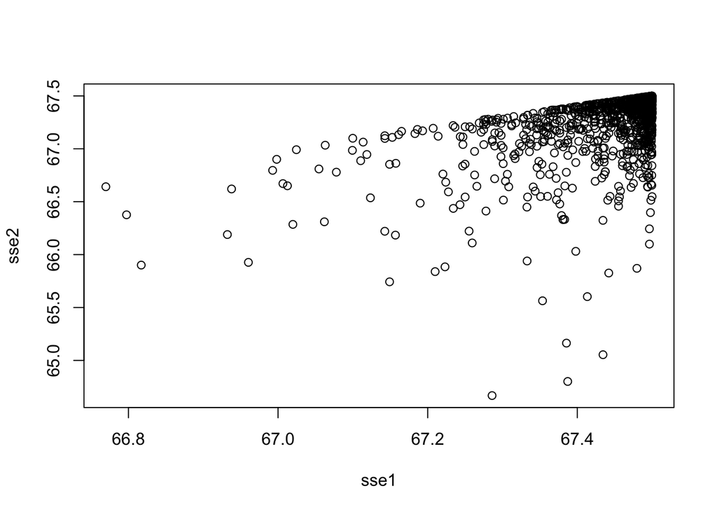

```r
plot(sse2 ~ sse1, dat)
```

For the trans-trans association:

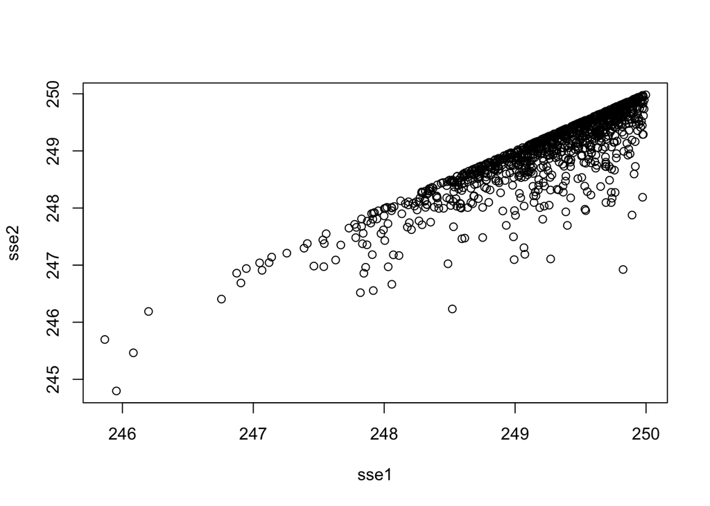

```r
plot(sse2 ~ sse1, dat2)
```

Checking the equation

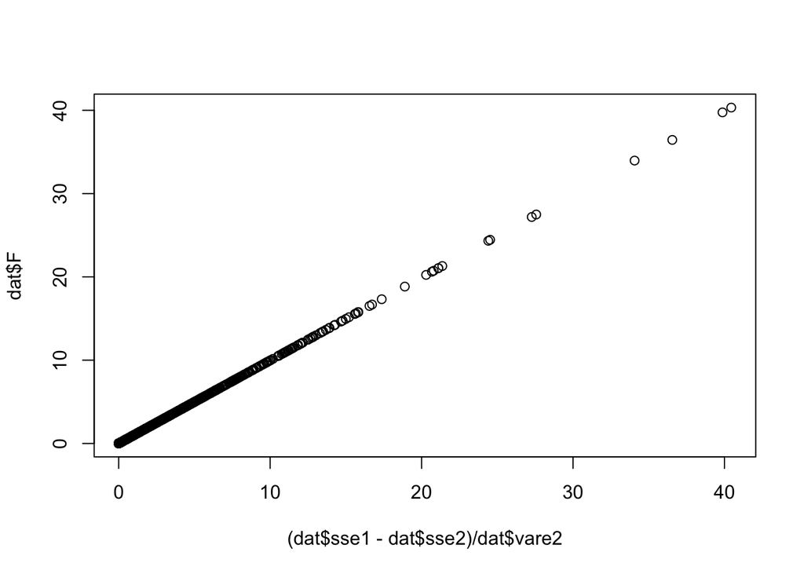

```r
plot((dat$sse1-dat$sse2)/dat$vare2, dat$F)
```

This works great but note that in the original document it was $SSE_2 - SSE_1$ which should be switched.

## Interaction test

Let the genotypic value of $y_{1.ij} = (y_1 = 1 | y_2 = i, y_3 = j)$ where $i,j \in \{0,1\}$, and the counts for each value be

$$n_{ij} = n ( 1- p_2 + i(2p_2) - 1))(1 - p_3 + i(2p_3-1))$$

We can therefore calculate the numbers in the 2 x 2 combinations of $y_2$ and $y_3$:

$$\begin{aligned}
y_2\; & y_3 & n_{ij}/n \\
0\; & 0 & (1 - p_2)(1 - p_3) \\
0\; & 1 & p_2(1 - p_3) \\
1\; & 0 & (1 - p_2)p_3 \\
1\; & 1 & p_2p_3 \\
\end{aligned}$$

A test for interaction can be defined as

$$\delta = mean(y_{1.11}) + mean(y_{1.00}) - mean(y_{1.10}) - mean(y_{1.01})$$

with $mean(y_{1.ij}) = \sum y_{1.ij} / n_{ij}$.

Check this. First generate a dataset with a strong interaction

```r
set.seed(sapply(l, function(x) x$amod$F[2]) %>% which.max)
dat <- gendat(1000)
mod1 <- lm(y1 ~ y2 + y3, dat)
mod2 <- lm(y1 ~ y2 + y3 + y2*y3, dat)
amod <- anova(mod1, mod2)

SSE1 <- sum(residuals(mod1)^2)
SSE2 <- sum(residuals(mod2)^2)
pchisq((SSE1 - SSE2) / (SSE2 / 996), 1, low=F)
```

```
## [1] 2.147259e-10
```

```r
pf((SSE1 - SSE2) / (SSE2 / 996), 1, 996, low=F)
```

```
## [1] 3.258773e-10
```

Now create one with a weak interaction:

```r
set.seed(sapply(l, function(x) x$amod$F[2]) %>% which.min)
datw <- gendat(1000)
modw1 <- lm(y1 ~ y2 + y3, datw)
modw2 <- lm(y1 ~ y2 + y3 + y2*y3, datw)
amodw <- anova(modw1, modw2)
```

Test for interaction:

```r
est_delta <- function(dat)
{
    n <- nrow(dat)
    obs = table(dat$y1, dat$y2) / nrow(dat) %>% c
    tab <- with(dat, tapply(y1, list(y2, y3), mean)) %>% c
    return(tibble(
        y1.00 = tab[1],
        y1.10 = tab[2],
        y1.01 = tab[3],
        y1.11 = tab[4],
        delta = y1.00 + y1.11 - y1.10 - y1.01,
        p1 = mean(dat$y1),
        p2 = mean(dat$y2),
        p3 = mean(dat$y3),
        p00 = obs[1],
        p10 = obs[2],
        p01 = obs[3],
        p11 = obs[4],
        D = obs[4] - mean(dat$y1) * mean(dat$y2)
    ))
}

# strong interaction
est_delta(dat)
```

```
## # A tibble: 1 x 13
##    y1.00 y1.10  y1.01 y1.11 delta    p1    p2    p3   p00   p10   p01   p11
##    <dbl> <dbl>  <dbl> <dbl> <dbl> <dbl> <dbl> <dbl> <dbl> <dbl> <dbl> <dbl>
## 1 0.0523 0.375 0.0474 0.712 0.341   0.1   0.1 0.474 0.855 0.045 0.045 0.055
## # … with 1 more variable: D <dbl>
```

```r
# weak interaction
est_delta(datw)
```

```
## # A tibble: 1 x 13
##    y1.00 y1.10  y1.01 y1.11    delta    p1    p2    p3   p00   p10   p01
##    <dbl> <dbl>  <dbl> <dbl>    <dbl> <dbl> <dbl> <dbl> <dbl> <dbl> <dbl>
## 1 0.0509 0.551 0.0491 0.549 -2.20e-4   0.1   0.1 0.519 0.855 0.045 0.045
## # … with 2 more variables: p11 <dbl>, D <dbl>
```

In the linear model the error variance is assumed to be the same in each cell of the 2 x 2 table and a pooled estimate is used.

Variance of $\delta$ can be calculated from the allele and haplotype frequencies and compared to its variance under a linear model (LM). Summarise each of 1000 simulations for cis-trans and trans-trans examples:

```r
# cis-trans
run_sim3 <- function(i, n=1000)
{
    set.seed(i)
    dat <- gendat(n)
    return(est_delta(dat))
}
m <- lapply(1:1000, function(i) run_sim3(i)) %>% bind_rows()

# trans-trans
run_sim4 <- function(i, n=1000)
{
    set.seed(i)
    dat <- tibble(
        y1=rbinom(n, 1, 0.5),
        y2=rbinom(n, 1, 0.5),
        y3=rbinom(n, 1, 0.5)
    )
    return(est_delta(dat))
}
m2 <- lapply(1:1000, function(i) run_sim4(i)) %>% bind_rows()
```

From the given haplotype frequencies:

$$\begin{aligned}
E(y_{1.11}) = E(y_{1.10}) &= p(y_1 = 1 | y_2 = 1) \\
&= p_{11} / p2 \\
&= p_1 + D / p_2
\end{aligned}$$

Check:

```r
mean(m$y1.11)
```

```
## [1] 0.5511654
```

```r
mean(m$y1.10)
```

```
## [1] 0.5487734
```

```r
(m$p11/m$p2)[1]
```

```
## [1] 0.55
```

```r
(m$p1 + m$D/m$p2)[1]
```

```
## [1] 0.55
```

and similarly

$$\begin{aligned}
E(y_{1.00}) = E(y_{1.01}) &= p(y_1 = 0 | y_2 = 0) \\
&= p_{00} / p2 \\
&= p_1 - D/(1 - p_2)
\end{aligned}$$

Check:

```r
mean(m$y1.00)
```

```
## [1] 0.04995842
```

```r
mean(m$y1.01)
```

```
## [1] 0.05002769
```

```r
(m$p1 - m$D/(1-m$p2))[1]
```

```
## [1] 0.05
```

Each of the terms has a binomial variance

$$var(mean(y_{1.ij})) = E(y_{1.ij})(1 - E(y1.ij)) / n_{ij}$$

Putting all the terms together gives the exact variance of the test statistic as

$$var(\delta) =
\frac{p_1(1-p_1) + \frac{(1-2p_1)(1-2p_2)D}{p2(1-p2)} - \frac{D^2(1-3p_2(1-p_2))}{p_2^2(1-p_2])^2} }
{n p_2(1-p_2)p_3(1-p_3)}$$

Check:

```r
# Variance of mean(y_1.11)
(sd(m$y1.11) / sqrt(nrow(m)))^2
```

```
## [1] 2.399398e-06
```

```r
# According to the formula
mean(m$y1.11) * (1 - mean(m$y1.11)) / mean((m$p2) * (m$p3) * 1000)
```

```
## [1] 0.004940705
```

**Don’t seem to be getting agreement here.**

The general idea that the variance of each term is differentseems to be correct though, as the variance of $var(mean(y_{1.ij}))$ is not consistent over $i$ and $j$

```r
(sd(m$y1.11) / sqrt(nrow(m)))^2
```

```
## [1] 2.399398e-06
```

```r
(sd(m$y1.10) / sqrt(nrow(m)))^2
```

```
## [1] 2.456226e-06
```

```r
(sd(m$y1.01) / sqrt(nrow(m)))^2
```

```
## [1] 5.399837e-08
```

```r
(sd(m$y1.00) / sqrt(nrow(m)))^2
```

```
## [1] 5.433426e-08
```

## Other aspects

### Adjusting for additive effects with varying degrees of measurement error

```r
gendatp <- function(n, p1, p2, p3, r1, shufprop)
{
    dat <- simulateGP:::simulate_haplotypes(n, r1, p1, p2) %>% as_tibble %>% dplyr::select(y1=A1, y2=B1)
    dat$y3 <- rbinom(n, 1, p3)
    dat$y4 <- dat$y1
    index <- sample(1:nrow(dat), shufprop * nrow(dat), replace=FALSE)
    dat$y4[index] <- sample(dat$y4[index])
    return(dat)
}

run_simp <- function(param, i)
{
    set.seed(i*10)
    dat <- gendatp(param$n[i], param$p1[i], param$p2[i], param$p3[i], param$r1[i], param$shufprop[i])
    # dat$y1r <- residuals(lm(y1 ~ y4, dat))
    x <- dat$y1 + rnorm(nrow(dat), sd=sd(dat$y1)/2)
    mod1 <- lm(x ~ y4 + y2 + y3, dat)
    mod2 <- lm(x ~ y4 + y2 + y3 + y2*y3, dat)
    amod <- anova(mod1, mod2)
    param$r2[i] <- cor(dat$y1, dat$y4)
    param$F[i] <- amod$F[2]
    return(param[i,])
}


param <- expand.grid(
    p1=0.1,
    p2=0.1,
    p3=0.5,
    p4=0.1,
    shufprop=seq(0, 1, by=0.1),
    n=1000,
    r1=seq(0, 1, by=0.2),
    sim=1:500,
    r2=NA,
    F=NA
)

resp <- lapply(1:nrow(param), function(x) run_simp(param, x)) %>% bind_rows()
```

Plot

```r
resp %>%
group_by(r1, shufprop) %>%
summarise(n=n(), mF=mean(F, na.rm=T), vF=var(F, na.rm=T), r2=mean(r2, na.rm=T)) %>% as.data.frame
```

```
##     r1 shufprop   n        mF        vF           r2
## 1  0.0      0.0 500 1.0687724  2.204605 1.0000000000
## 2  0.0      0.1 500 1.0262969  2.180180 0.9016000000
## 3  0.0      0.2 500 1.1126969  2.659215 0.7998000000
## 4  0.0      0.3 500 0.9408947  1.763981 0.7008888889
## 5  0.0      0.4 500 1.0149585  2.008133 0.5986222222
## 6  0.0      0.5 500 1.0107460  1.673330 0.5008222222
## 7  0.0      0.6 500 1.1132516  2.345374 0.4017111111
## 8  0.0      0.7 500 0.9256268  1.532299 0.3010000000
## 9  0.0      0.8 500 0.9424840  1.734563 0.2021111111
## 10 0.0      0.9 500 1.0042538  1.850972 0.0973111111
## 11 0.0      1.0 500 0.9807542  1.822225 0.0006222222
## 12 0.2      0.0 500 1.0775958  2.186662 1.0000000000
## 13 0.2      0.1 500 1.3740653  3.766824 0.8995111111
## 14 0.2      0.2 500 1.5739581  6.661615 0.7998888889
```

[output cut: 52 more lines]

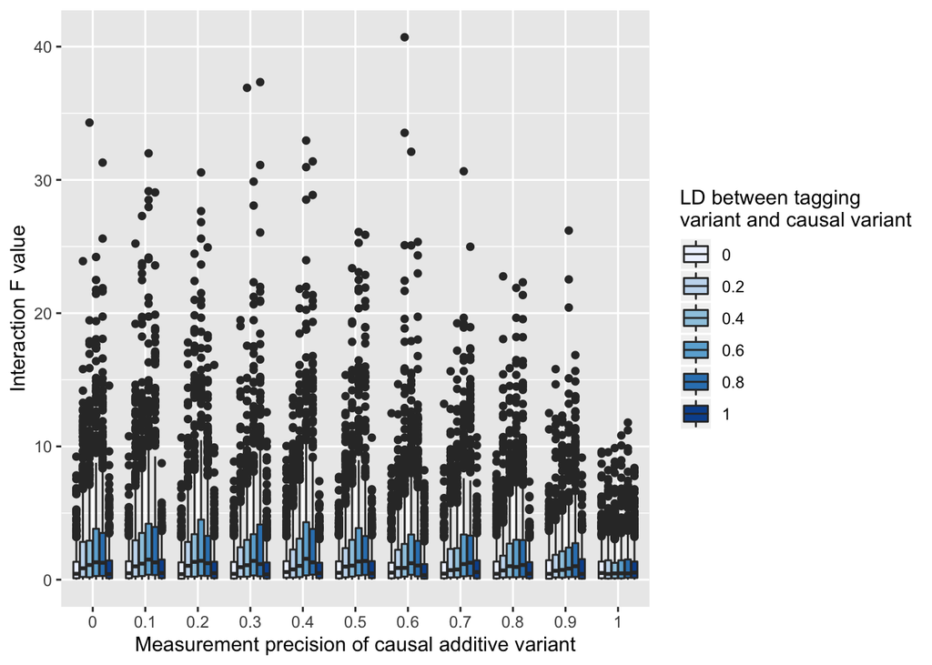

```r
resp$R2 <- 1 - resp$shufprop
ggplot(resp, aes(x=as.factor(R2), y=F)) +
geom_boxplot(aes(fill=as.factor(r1))) +
scale_fill_brewer(type="seq") +
labs(y="Interaction F value", x="Measurement precision of causal additive variant", fill="LD between tagging\nvariant and causal variant")
```

## Point estimation

A model where the average additive effect is different from the per-individual additive effect. The error term in the model is now a mixture of variance not explained by the SNP and heterogeneity in the effect of the SNP across the population.

```r
simulate_phen <- function(x, meanb, varb, r2)
{
    n <- length(x)
    b <- rnorm(n, meanb, sqrt(varb))
    yp <- x * b
    myb <- x * meanb
    vhet <- var(yp) - var(x * meanb)
    r2het <- cor(myb, yp)^2
    ve <- (var(myb) - r2 * var(myb)) / r2
    y <- yp + rnorm(n, 0, sqrt(ve - vhet))
    m <- try(lm(y ~ x)$coef[2])
    m <- ifelse(class(m) == 'try-error', NA, m)
    return(
        list(
            y=y,
            info=tibble(
                varb=varb,
                r2=r2,
                r2het=r2het,
                rsqxy=cor(x,y)^2,
                ve=ve,
                vy=var(y),
                vyp=var(yp),
                vhet=vhet,
                bhat=m
            )
        )
    )
}

x <- rbinom(10000, 1, 0.5)
out <- expand.grid(meanb=1, varb=seq(0.0, 0.5, by=0.02), r2=seq(0.1, 1, by=0.1)) %>%
    split(., 1:nrow(.)) %>%
    lapply(., function(i) simulate_phen(x, i$meanb, i$varb, i$r2)$info) %>% bind_rows()
```

[output not shown]

[output cut: 129 more lines]

[output not shown]

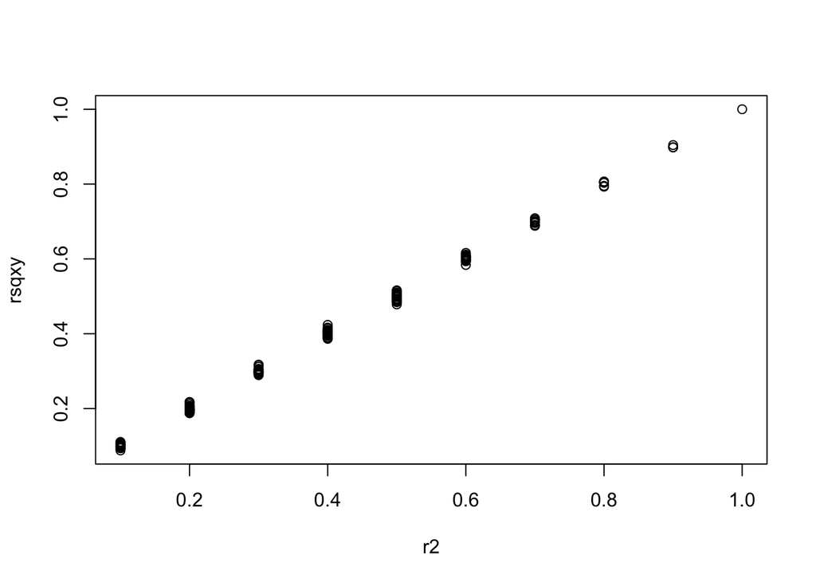

```r
plot(rsqxy ~ r2, out)
```

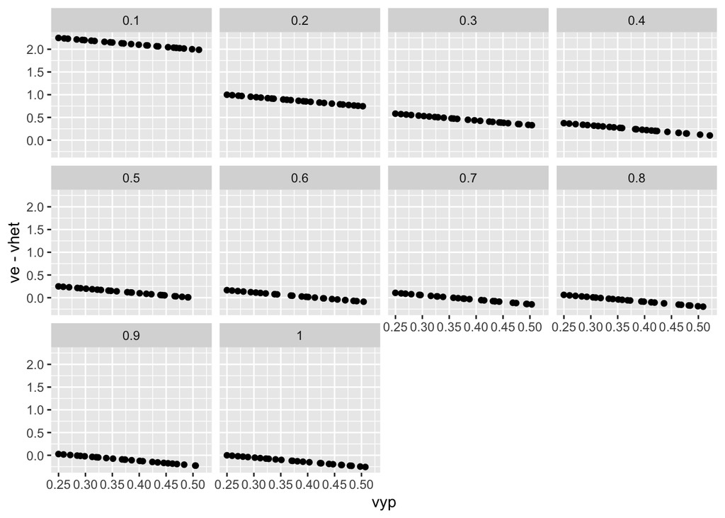

```r
ggplot(out, aes(x=vyp, y=ve-vhet)) +
geom_point() +
facet_wrap(~ r2 )
```

Run simulations to see how point estimation heterogeneity impacts F statistic in interaction test.

```r
run_simp2 <- function(param, i)
{
    set.seed(i)
    dat <- gendatp(param$n[i], param$p1[i], param$p2[i], param$p3[i], param$r1[i], param$shufprop[i])
    o <- simulate_phen(dat$y1, param$meanb[i], param$varb[i], param$r2add[i])
    x <- o$y
    info <- o$info
    mod1 <- lm(x ~ y1 + y3, dat)
    mod2 <- lm(x ~ y1 + y3 + y1*y3, dat)
    amod <- anova(mod1, mod2)
    param$r2[i] <- cor(dat$y1, x)
    param$F[i] <- amod$F[2]
    param$ve <- info$ve
    param$vhet <- info$vhet
    param$rsqxy <- info$rsqxy
    param$vy <- info$vy

    return(param[i,])
}

param <- expand.grid(
    p1=0.1,
    p2=0.1,
    p3=0.5,
    p4=0.1,
    shufprop=0,
    r2add=0.5,
    meanb=1,
    varb=seq(0, 0.4, by=0.01),
    n=1000,
    r1=0.5,
    sim=1:1000,
    r2=NA,
    F=NA
)

res <- lapply(1:nrow(param), function(x) run_simp2(param, x)) %>% bind_rows()

res %>%
group_by(r1, varb) %>%
summarise(
    n=n(),
    mF=mean(F, na.rm=T),
    vF=var(F, na.rm=T),
    r2=mean(r2, na.rm=T),
    ve=mean(ve, na.rm=T),
    vhet=mean(vhet, na.rm=T),
    rsqxy=mean(rsqxy, na.rm=T),
    vy=mean(vy, na.rm=T)
) %>% as.data.frame
```

```
##     r1 varb    n       mF        vF        r2         ve        vhet
## 1  0.5 0.00 1000 1.033905  2.003921 0.7072025 0.09009009 0.000000000
## 2  0.5 0.01 1000 1.210412  3.005683 0.7079316 0.09009009 0.001101910
## 3  0.5 0.02 1000 1.233206  2.485183 0.7079709 0.09009009 0.002010058
## 4  0.5 0.03 1000 1.339384  3.695988 0.7075927 0.09009009 0.003065627
## 5  0.5 0.04 1000 1.369299  3.382434 0.7072014 0.09009009 0.004133349
## 6  0.5 0.05 1000 1.623593  5.392909 0.7063864 0.09009009 0.004838796
## 7  0.5 0.06 1000 1.697867  5.143743 0.7068376 0.09009009 0.005946396
## 8  0.5 0.07 1000 1.579992  4.808797 0.7083143 0.09009009 0.007250882
## 9  0.5 0.08 1000 1.824044  6.357862 0.7057168 0.09009009 0.007670644
## 10 0.5 0.09 1000 1.829303  7.492599 0.7089057 0.09009009 0.009574279
## 11 0.5 0.10 1000 1.744970  6.586363 0.7064233 0.09009009 0.010138966
## 12 0.5 0.11 1000 1.975033  8.647910 0.7089888 0.09009009 0.011463175
## 13 0.5 0.12 1000 2.144571  8.499256 0.7059070 0.09009009 0.011660979
## 14 0.5 0.13 1000 2.098522  9.397899 0.7069901 0.09009009 0.013091949
```

[output cut: 69 more lines]

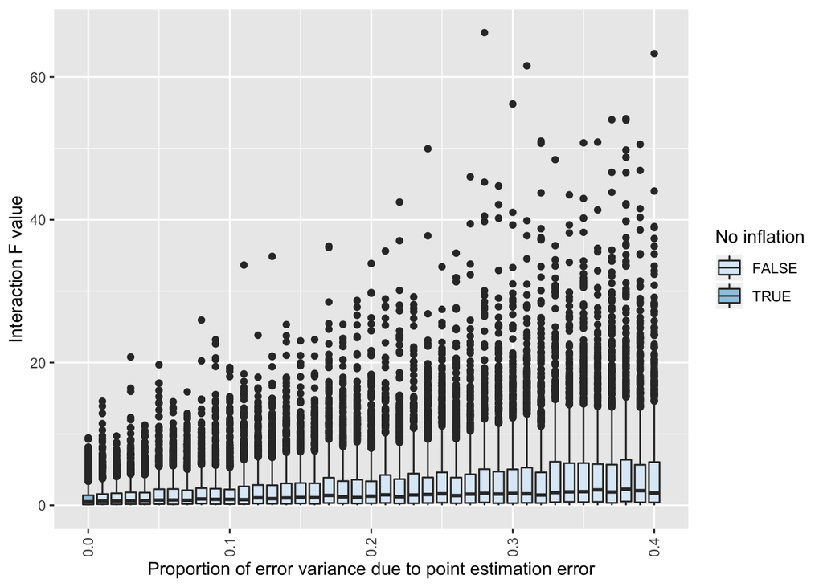

```r
res$vhetvy <- res$vhet/res$vy
res$vhetvy[res$vhetvy < 0] <- 0
res$vhetvy <- cut(res$vhetvy, breaks=10)
ggplot(res, aes(x=varb, y=F)) +
geom_boxplot(aes(group=as.factor(varb), fill=varb==0)) +
scale_fill_brewer(type="seq") +
labs(y="Interaction F value", x="Proportion of error variance due to point estimation error", fill="No inflation") +
theme(axis.text.x=element_text(angle=90, hjust=1, vjust=0.5))
```